# Analyse

Author

Soriba SYLLA (soribasyllakamsar@gmail.com)

# Analyse de données

Kaggle Dataset: https://www.kaggle.com/datasets/vivek468/superstore-dataset-final

## **Contexte**

Face à une demande croissante et à une concurrence féroce, une grande enseigne de distribution sollicite votre expertise pour identifier les stratégies les plus performantes. Elle souhaite déterminer les produits, régions, catégories et segments de clientèle à cibler ou à éviter.

Laissez libre cours à votre imagination avec les données, mais veillez également à fournir des informations commerciales pertinentes pour les améliorer.

## Importation des libraries

```r
library(readxl)
library(dplyr)
library(forcats)
library(lubridate)
library(gtsummary)
library(naniar)
library(ggplot2)
library(scales)
library(plotly)
library(stringr)
library(prophet)
```

## Importation du Dataset

```r
df <- read_excel("data/Sample - Superstore.xlsx", col_types = "text")
```

## Traitement des données

### Visualisation du Dataset

```r
View(df)
```

### Visualisation des valeurs manquantes

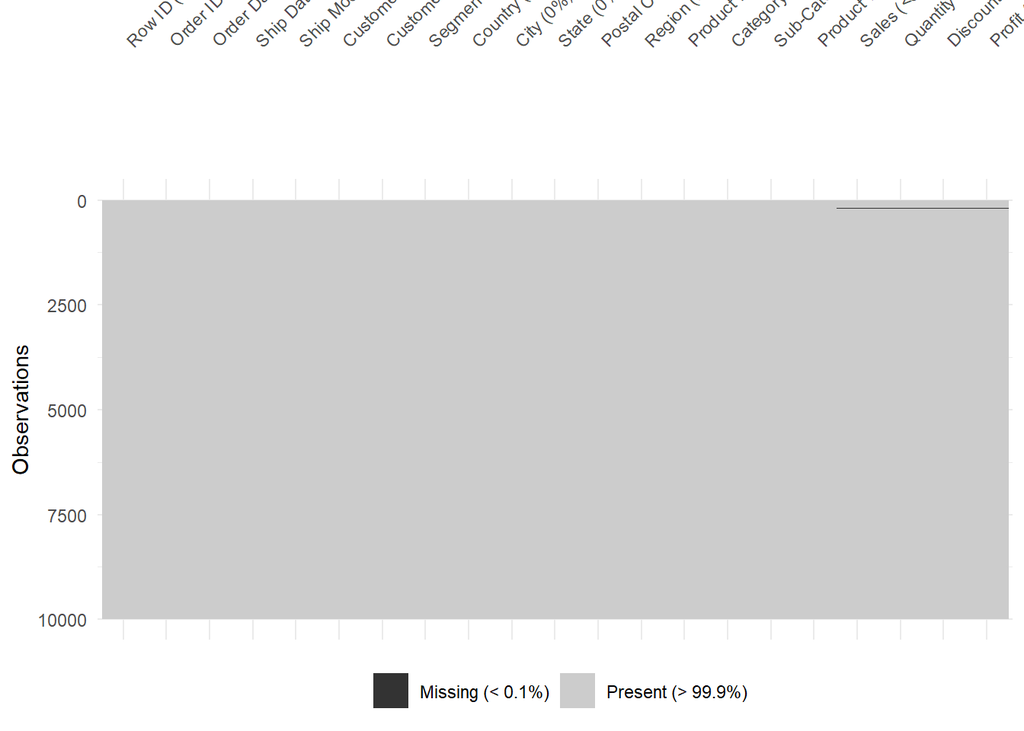

```r
vis_miss(df)
```

Nous remarquons que notre jeu de données contient moins de 0,1 % de valeurs manquantes. Nous allons verifier les colonnes et les produits qui sont concernées afin de prendre une décision sur la méthodologie de gestion approprié.

```r
colSums(is.na(df))
```

```
       Row ID      Order ID    Order Date     Ship Date     Ship Mode
            0             0             0             0             0
  Customer ID Customer Name       Segment       Country          City
            0             0             0             0             0
        State   Postal Code        Region    Product ID      Category
            0             0             0             0             0
 Sub-Category  Product Name         Sales      Quantity      Discount
            0             0             6             6             6
       Profit
            6
```

```r
manquant <- df |> filter(is.na(Sales) | is.na(Quantity) | is.na(Discount) | is.na(Profit)) |> select(`Product Name`, Sales, Quantity, Discount, Profit)
manquant
```

```
# A tibble: 6 × 5
  `Product Name`                                  Sales Quantity Discount Profit
  <chr>                                           <chr> <chr>    <chr>    <chr>
1 Imation Secure+ Hardware Encrypted USB 2.0 Fla… <NA>  <NA>     <NA>     <NA>
2 Imation Secure+ Hardware Encrypted USB 2.0 Fla… <NA>  <NA>     <NA>     <NA>
3 Imation Secure+ Hardware Encrypted USB 2.0 Fla… <NA>  <NA>     <NA>     <NA>
4 Imation Secure+ Hardware Encrypted USB 2.0 Fla… <NA>  <NA>     <NA>     <NA>
5 Imation Secure+ Hardware Encrypted USB 2.0 Fla… <NA>  <NA>     <NA>     <NA>
6 Imation Secure+ Hardware Encrypted USB 2.0 Fla… <NA>  <NA>     <NA>     <NA>
```

Les valeurs manquantes concernent un seul et même produit; et n’ayant aucune information sur les ventes de ce produits précis, je décide de les éliminer et de ne pas en tenir compte lors de l’analyse.

```r
df <- df |>
  filter(!(is.na(Sales) | is.na(Quantity) | is.na(Discount) | is.na(Profit)))
```

### **Uniformisation des dates**

#### Order date

```r
df$order_date_clear <- as.Date(as.numeric(df$`Order Date`), origin = "1899-12-30")
```

```r
df <- df |> mutate(
  order_date_clear = coalesce(order_date_clear, parse_date_time(df$`Order Date`, orders = c("mdy")))
)
df <- df |> select(- `Order Date`) |> rename(order_date = order_date_clear)
```

#### Ship date

```r
df$ship_date_clear <- as_date(as.numeric(df$`Ship Date`), origin="1899-12-30");
df <- df |> mutate(
  ship_date_clear = coalesce(ship_date_clear, parse_date_time(df$`Ship Date`, orders = "mdy"))
)
df <- df |> select(- `Ship Date`) |> rename(ship_date = ship_date_clear)
```

#### Verification des l’étendues des dates

```r
summary(df$ship_date)
```

```
                 Min.               1st Qu.                Median
"2014-01-04 00:00:00" "2015-05-07 00:00:00" "2016-06-12 00:00:00"
                 Mean               3rd Qu.                  Max.
"2016-04-20 15:55:52" "2017-04-29 00:00:00" "2018-05-01 00:00:00"
```

```r
summary(df$order_date)
```

```
                 Min.               1st Qu.                Median
"2014-01-02 00:00:00" "2015-05-01 00:00:00" "2016-05-30 00:00:00"
                 Mean               3rd Qu.                  Max.
"2016-04-11 08:18:24" "2017-04-09 00:00:00" "2017-12-30 00:00:00"
```

### Typage des colonnes

```r
df <- df |> mutate(
  `Order ID` = as_factor(`Order ID`),
  `Ship Mode` = as_factor(`Ship Mode`),
  `Customer ID` = as_factor(`Customer ID`),
  `Customer Name` = as_factor(`Customer Name`),
  Segment = as_factor(Segment),
  City = as_factor(City),
  State = as_factor(State),
  `Postal Code` = as_factor(`Postal Code`),
  Region = as_factor(Region),
  Category = as_factor(Category),
  `Sub-Category` = as_factor(`Sub-Category`),
  `Product Name` = as_factor(`Product Name`),
  Sales = as.numeric(Sales),
  Quantity = as.numeric(Quantity),
  Discount = as.numeric(Discount),
  Profit = as.numeric(Profit),
  order_date = as_date(order_date),
  ship_date = as_date(ship_date),
)
```

### Definition des colonnes

```r
df <- df |> mutate(
  order_year = year(df$order_date),
  marge = (Profit/Sales) * 100
)
```

### Visualisation du dataframe

```r
glimpse(df)
```

```
Rows: 9,988
Columns: 23
$ `Row ID`        <chr> "1", "2", "3", "4", "5", "6", "7", "8", "9", "10", "11…
$ `Order ID`      <fct> CA-2016-152156, CA-2016-152156, CA-2016-138688, US-201…
$ `Ship Mode`     <fct> Second Class, Second Class, Second Class, Standard Cla…
$ `Customer ID`   <fct> CG-12520, CG-12520, DV-13045, SO-20335, SO-20335, BH-1…
$ `Customer Name` <fct> Claire Gute, Claire Gute, Darrin Van Huff, Sean O'Donn…
$ Segment         <fct> Consumer, Consumer, Corporate, Consumer, Consumer, Con…
$ Country         <chr> "United States", "United States", "United States", "Un…
$ City            <fct> Henderson, Henderson, Los Angeles, Fort Lauderdale, Fo…
$ State           <fct> Kentucky, Kentucky, California, Florida, Florida, Cali…
$ `Postal Code`   <fct> 42420, 42420, 90036, 33311, 33311, 90032, 90032, 90032…
$ Region          <fct> South, South, West, South, South, West, West, West, We…
$ `Product ID`    <chr> "FUR-BO-10001798", "FUR-CH-10000454", "OFF-LA-10000240…
$ Category        <fct> Furniture, Furniture, Office Supplies, Furniture, Offi…
$ `Sub-Category`  <fct> Bookcases, Chairs, Labels, Tables, Storage, Furnishing…
$ `Product Name`  <fct> "Bush Somerset Collection Bookcase", "Hon Deluxe Fabri…
$ Sales           <dbl> 261.9600, 731.9400, 14.6200, 957.5775, 22.3680, 48.860…
$ Quantity        <dbl> 2, 3, 2, 5, 2, 7, 4, 6, 3, 5, 9, 4, 3, 3, 5, 3, 6, 2, …
$ Discount        <dbl> 0.00, 0.00, 0.00, 0.45, 0.20, 0.00, 0.00, 0.20, 0.20, …
$ Profit          <dbl> 41.9136, 219.5820, 6.8714, -383.0310, 2.5164, 14.1694,…
$ order_date      <date> 2016-08-11, 2016-08-11, 2016-12-06, 2015-11-10, 2015-…
$ ship_date       <date> 2016-11-11, 2016-11-11, 2016-06-16, 2015-10-18, 2015-…
$ order_year      <dbl> 2016, 2016, 2016, 2015, 2015, 2014, 2014, 2014, 2014, …
$ marge           <dbl> 16.000000, 30.000000, 47.000000, -40.000000, 11.250000…
```

## 1- Analyse descriptive

### Configuration de gtsummary

```r
theme_gtsummary_language(language = "fr", decimal.mark = ",", big.mark = " ")
```

```
Setting theme "language: fr"
```

#### a - Chiffre d’affaire total, le total des profit réalisés et le pourcentage que represente ce profit du chiffre d’affaire

```r
df |> summarise(
  `Chiffre d'affaire total` = sum(Sales),
  `Total du profit réalisé` = sum(Profit),
  `Marge du profit` = (`Total du profit réalisé` / `Chiffre d'affaire total`) * 100
)
```

```
# A tibble: 1 × 3
  `Chiffre d'affaire total` `Total du profit réalisé` `Marge du profit`
                      <dbl>                     <dbl>             <dbl>
1                  2295274.                   285988.              12.5
```

Sur la période allant de 2014 à la fin de l’année 2017, cette entreprise a réalisé un chiffre d’affaires cumulé de 2 295 274 dollars. Au cours de cette période, elle a dégagé un bénéfice de 285 988,30 dollars, soit une marge de 12,46 % du chiffre d’affaires total.

#### Réprésentation graphique par année

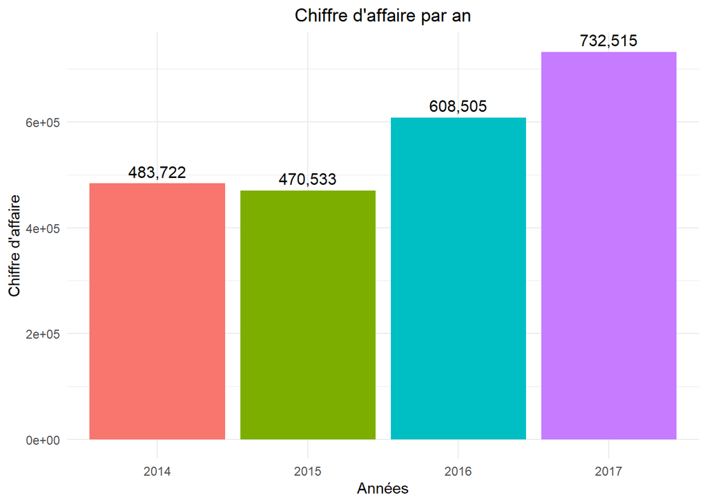

```r
df |>
  group_by(order_year) |>
  summarise(montant_total_annee = sum(Sales)) |>
  ggplot(aes(x=as.factor(order_year), y=montant_total_annee, fill=as.factor(order_year))) +
  geom_col(show.legend = FALSE) +
  geom_text(
    aes(label = comma(montant_total_annee)),
    vjust = -0.5,
    size = 4
  ) + labs(
    x = "Années",
    y = "Chiffre d'affaire",
    title = "Chiffre d'affaire par an"
  ) +
  theme_minimal() +
  theme(
    plot.title = element_text(hjust = .5)
  )
```

Le chiffre d’affaires est passé de 483 722 dollars en 2014 à 732 515 dollars en 2017, ce qui traduit une forte croissance durant cette période. L’inspection de ce graphique nous permet de distinguer deux phases de cette croissance :

- **2014 - 2015** : Durant cette période, la croissance du chiffre d’affaires de l’entreprise est plutôt stable, avec une faible régression en 2015, passant ainsi de 483 722 dollars à 470 533 dollars.
- **2016 - 2017** : Nous constatons une explosion du chiffre d’affaires de l’entreprise, qui passe de 470 533 dollars à 608 505 dollars en 2016, et cette croissance se poursuit en 2017 pour atteindre les 732 515 dollars.